# HW3

Author

Caitlin Nordheim-Maestas, Kat Le

Load libraries

```r
library(tidyverse)
library(janitor)
library(here)
library(purrr)
library(ggpubr)
```

Load data

```r
# tidy data so that it's a dataframe where each column is a numeric
data = read.table(here::here("clim.txt"), header=T)
```

Load crop_yield function

```r
source(here::here("crop_yield.R"))
source(here::here("crop_profit.R"))
```

```r
crop_summary <- crop_yield("almonds", data)
crop_profit_base <- crop_profit(yield_data = crop_summary)
```

### Single parameter sensitivity: vary revenue

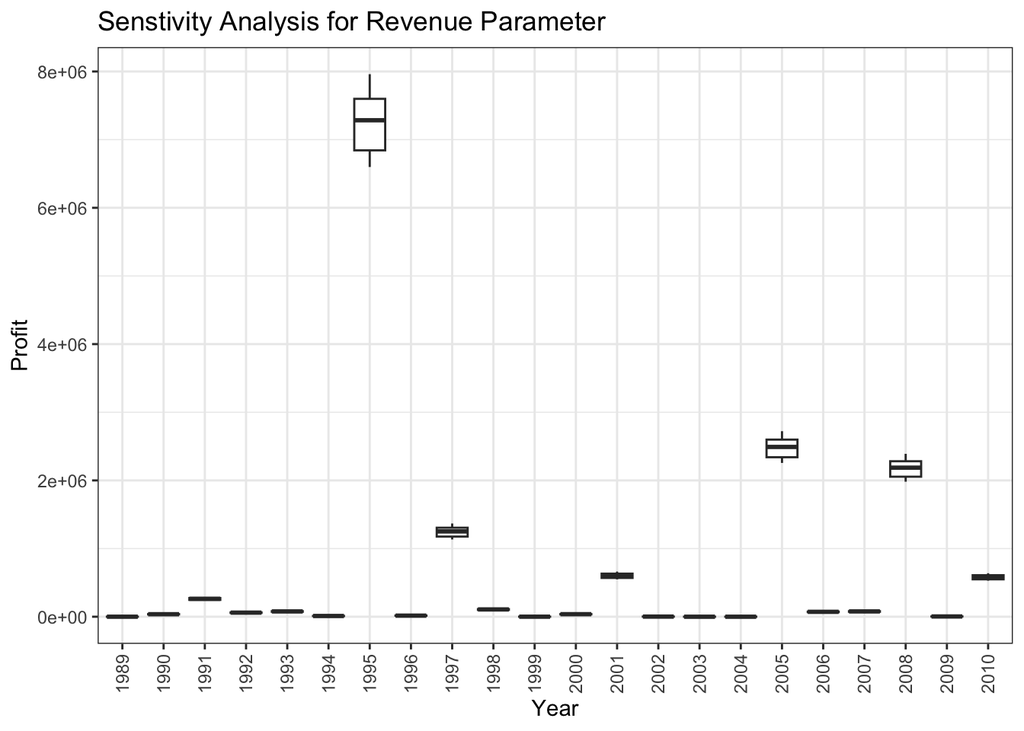

```r
# assume a uniform distribution of 22 samples

deviation = 0.10
base_revenue = 3800
revenue = runif(min=base_revenue-deviation*base_revenue,
                max = base_revenue+deviation*base_revenue, n=22)

# now run our model for the parameters
almond_profit = revenue %>% map(~crop_profit(yield_data = crop_summary,
                        cost_irrig = 530,
                        cost_nonirrig = 3367,
                      revenue =.x ))

# extract a useful data structure and reformat as a data frame with nice column names
tmp = map_df(almond_profit, `[`, c("year",
                                   "yield", "profit"))


almond_df = data.frame(year = tmp$year,
                       yield = tmp$yield,
                       profit = tmp$profit,
                       revenue = revenue)


# now we could plot
sens_plot1 <- ggplot(almond_df,
       aes(as.factor(year), profit, group=year))+
  geom_boxplot()+
  labs(y="Profit", x="Year",
       title = "Senstivity Analysis for Revenue Parameter") +
  theme_bw() +
  theme(axis.text.x = element_text(angle = 90, vjust = 0.5))
sens_plot1
```

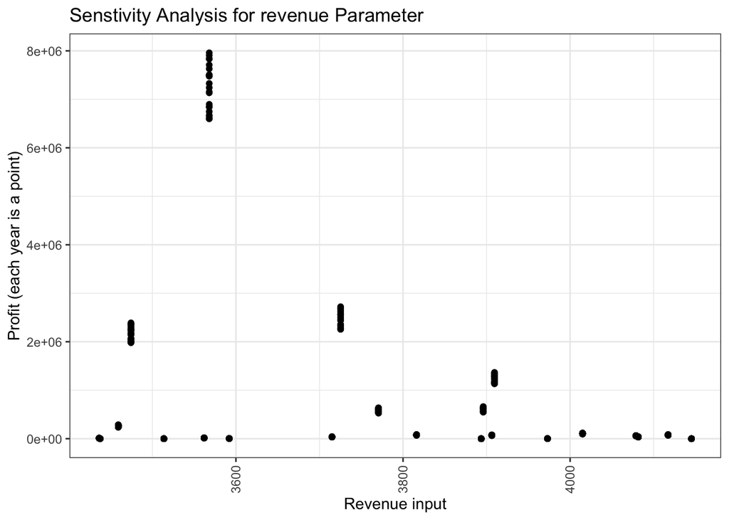

```r
rev_prof_plot <- ggplot(data = tmp, aes(x = revenue, y = profit)) +
  geom_point()

sens_plot_a2 <- almond_df %>%
  ggplot(aes(y = profit, x = revenue))+
  geom_point()+
  labs(y="Profit (each year is a point)", x="Revenue input",
       title = "Senstivity Analysis for revenue Parameter") +
  theme_bw() +
  theme(axis.text.x = element_text(angle = 90, vjust = 0.5))
sens_plot_a2
```

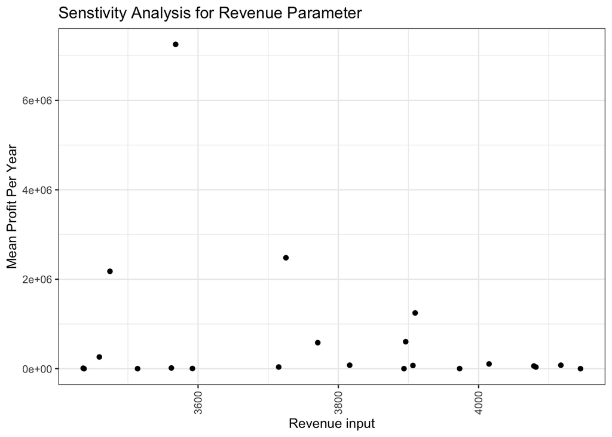

```r
# let's look at the mean profit over all time with ucertainty in revenue

# step 1: make a df that has the means for each year of profit
mean = almond_df %>%
  dplyr::select(-year, -yield) %>%
  group_by(revenue) %>%
  summarize(profit = mean(profit))

# step 2: plot it
sens_plot_a3 <- mean %>%
  ggplot(aes(y = profit, x = revenue))+
  geom_point()+
  labs(y="Mean Profit Per Year", x="Revenue input",
       title = "Senstivity Analysis for Revenue Parameter") +
  theme_bw() +
  theme(axis.text.x = element_text(angle = 90, vjust = 0.5))
sens_plot_a3
```

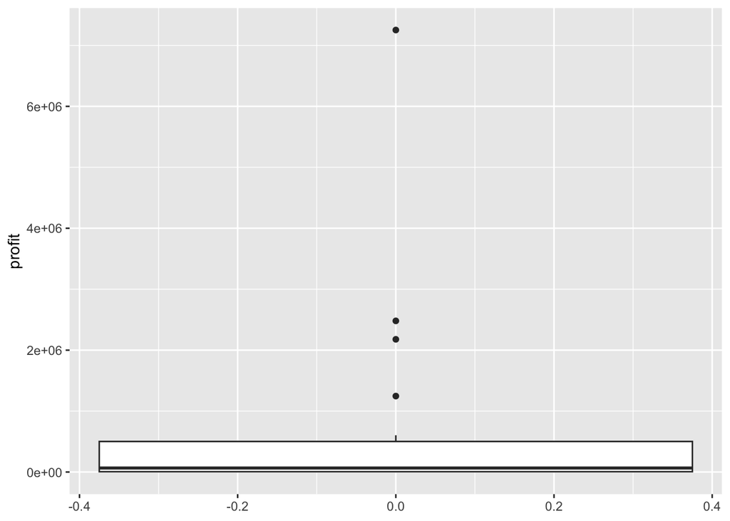

```r
# show the profit
ggplot(mean, aes(y=profit))+geom_boxplot()
```

### Can it be this easy??

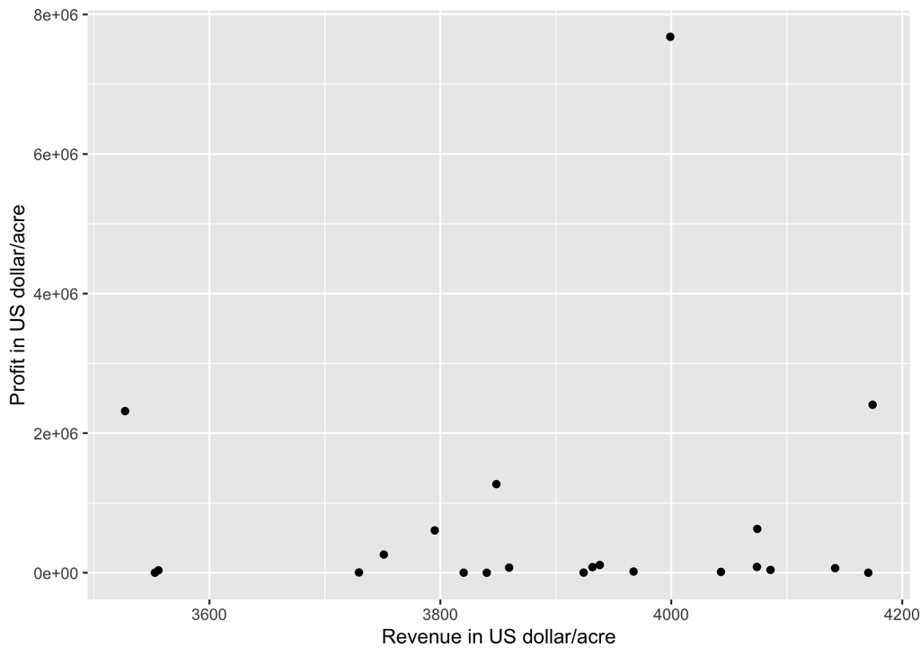

```r
# generate some test data for revenue
deviation = 0.10
base_revenue = 3800
revenue = runif(min=base_revenue-deviation*base_revenue,
                max = base_revenue+deviation*base_revenue, n=22)

# create a data frame to store results of model run
profit_estimate = cbind.data.frame(revenue=revenue, estimate=crop_profit(yield_data = crop_summary, revenue = revenue))

# graph the profit estimate for each input of revenue
ggplot(profit_estimate,aes(revenue, estimate.profit) )+geom_point()+labs(y="Profit in US dollar/acre", x="Revenue in US dollar/acre")
```

### Single parameter sensitivity: vary irrigation cost

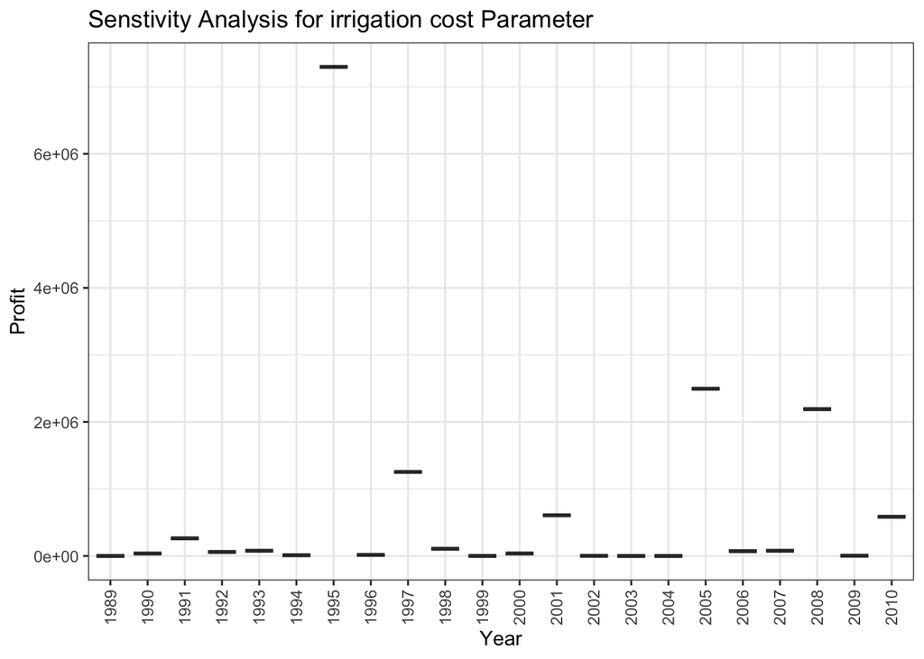

```r
# assume a uniform distribution of 20 samples
nsamples = 22
deviation = 0.1
base_irrig = 530
irrig = runif(min=base_irrig-deviation*base_irrig,
                max = base_irrig+deviation*base_irrig, n=nsamples)


# now run our model for the parameters
almond_profit_irrig = irrig %>% map(~crop_profit(yield_data = crop_summary,
                      cost_nonirrig = 3367,
                      revenue = 3800,
                       cost_irrig = .x ))

# extract a useful data structure and reformat as a data frame with nice column names
tmp = map_df(almond_profit_irrig, `[`, c("year",
                                   "yield", "profit"))


almond_df_irrig = data.frame(year = tmp$year,
                       yield = tmp$yield,
                       profit = tmp$profit,
                       irrig = irrig)


# now we could plot the sensitivity to irrigation costs by year
sens_plot_i1 <- ggplot(almond_df_irrig,
       aes(as.factor(year), profit, group=year))+
  geom_boxplot()+
  labs(y="Profit", x="Year",
       title = "Senstivity Analysis for irrigation cost Parameter") +
  theme_bw() +
  theme(axis.text.x = element_text(angle = 90, vjust = 0.5))
sens_plot_i1
```

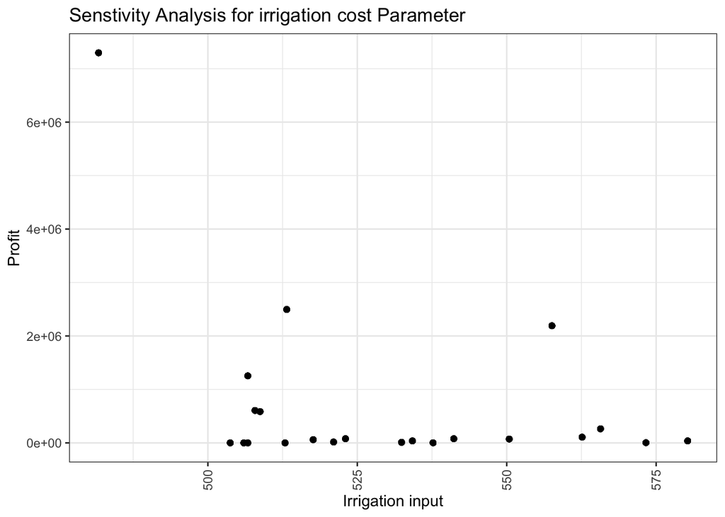

```r
# now we could plot irrigation input vs profit

sens_plot_i2 <- almond_df_irrig %>%
  ggplot(aes(y = profit, x = irrig))+
  geom_point()+
  labs(y="Profit", x="Irrigation input",
       title = "Senstivity Analysis for irrigation cost Parameter") +
  theme_bw() +
  theme(axis.text.x = element_text(angle = 90, vjust = 0.5))
sens_plot_i2
```

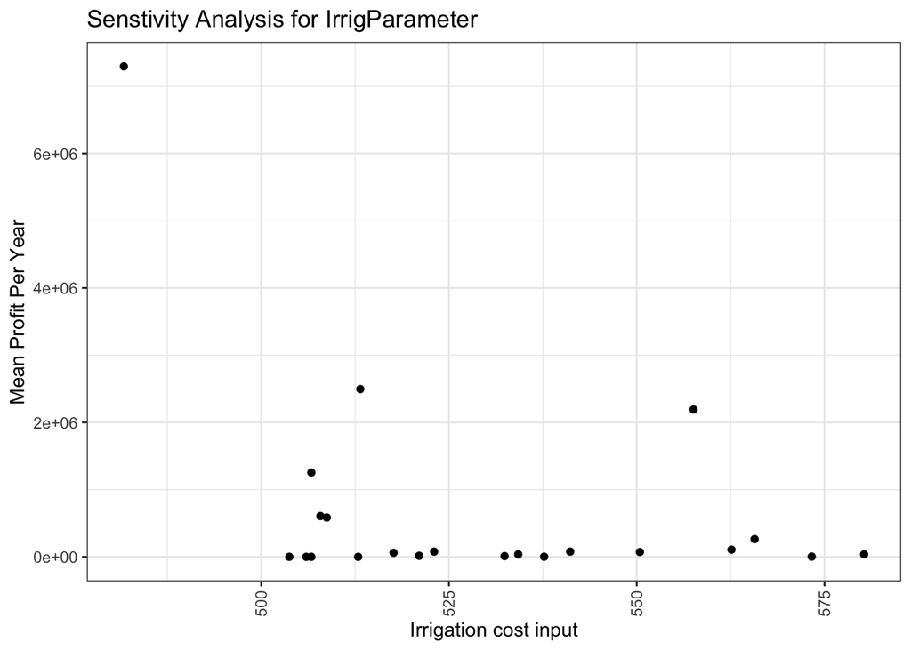

```r
# step 1: make a df that has the means for each year of profit
mean = almond_df_irrig %>%
  dplyr::select(-year, -yield) %>%
  group_by(irrig) %>%
  summarize(profit = mean(profit))

# step 2: plot it
sens_plot_i3 <- mean %>%
  ggplot(aes(y = profit, x = irrig))+
  geom_point()+
  labs(y="Mean Profit Per Year", x="Irrigation cost input",
       title = "Senstivity Analysis for IrrigParameter") +
  theme_bw() +
  theme(axis.text.x = element_text(angle = 90, vjust = 0.5))
sens_plot_i3
```

### Can it be this easy??

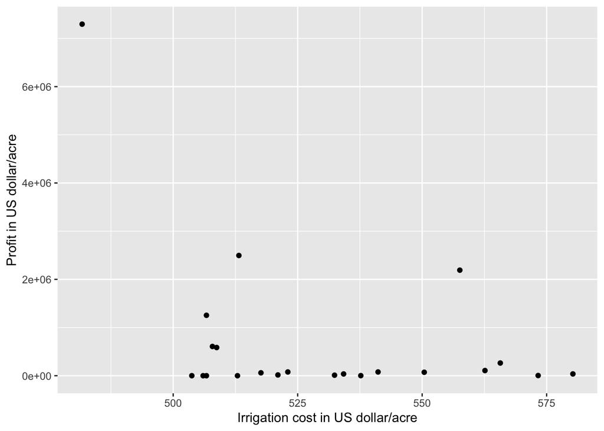

```r
# generate some test data for revenue
# nsamples = 22
# deviation = 0.1
# base_irrig = 530
# irrig = runif(min=base_irrig-deviation*base_irrig,
#                 max = base_irrig+deviation*base_irrig, n=nsamples)

# create a data frame to store results of model run
profit_estimate = cbind.data.frame(irrig=irrig, estimate=crop_profit(yield_data = crop_summary, cost_irrig=irrig))

# graph the profit estimate for each input of revenue
ggplot(profit_estimate,aes(irrig, estimate.profit) )+geom_point()+labs(y="Profit in US dollar/acre", x="Irrigation cost in US dollar/acre")
```

### Combined parameter sensitivity

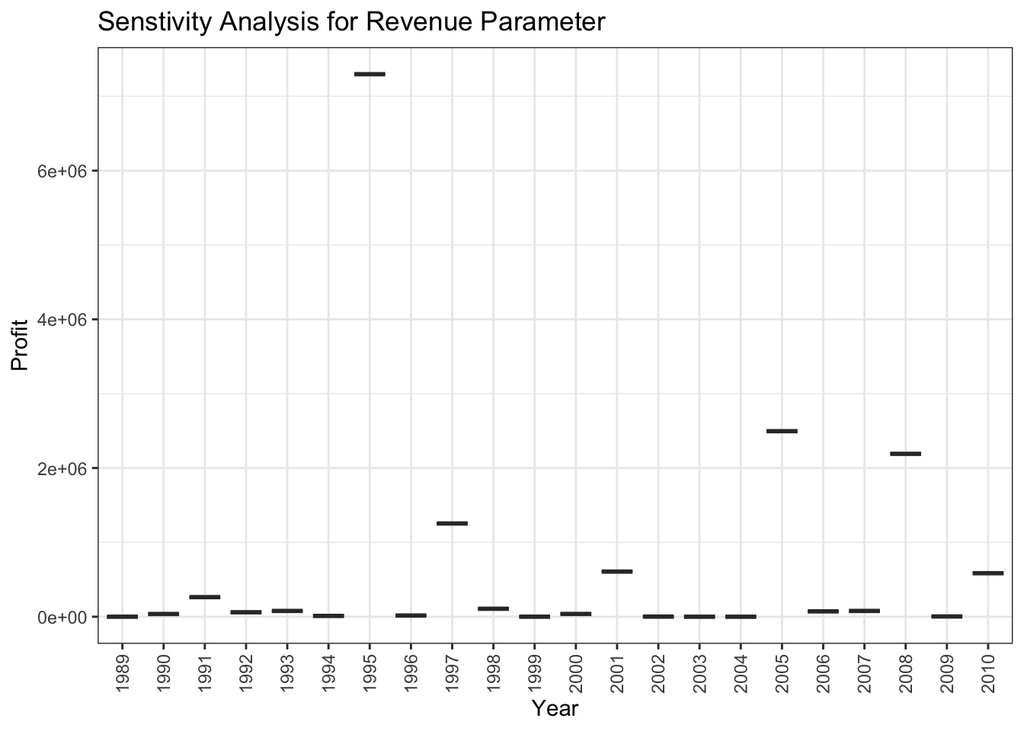

```r
# assume a uniform distribution of 20 samples
nsamples = 300
deviation = 0.15
base_revenue = 3800
revenue = runif(min=base_revenue-deviation*base_revenue,
                max = base_revenue+deviation*base_revenue, n=nsamples)

cost_irrig = rnorm(mean = 530, sd = 0.1, n = nsamples)

parms = cbind.data.frame(cost_irrig, revenue)

# now run our model for the parameters
results = parms %>% pmap(~crop_profit(yield_data = crop_summary,
                        cost_irrig = 530,
                        cost_nonirrig = 3367,
                        revenue = 3800))

# now we can extract results from the list as above
profit = map_df(results,`[`, c("year", "yield", "profit"))

# and we can add the parameter values for each run
profit = cbind.data.frame(profit, parms)


# now we could plot
sens_plot1 <- ggplot(profit,
       aes(as.factor(year), profit, group=year))+
  geom_boxplot()+
  labs(y="Profit", x="Year",
       title = "Senstivity Analysis for Revenue Parameter") +
  theme_bw() +
  theme(axis.text.x = element_text(angle = 90, vjust = 0.5))
sens_plot1
```

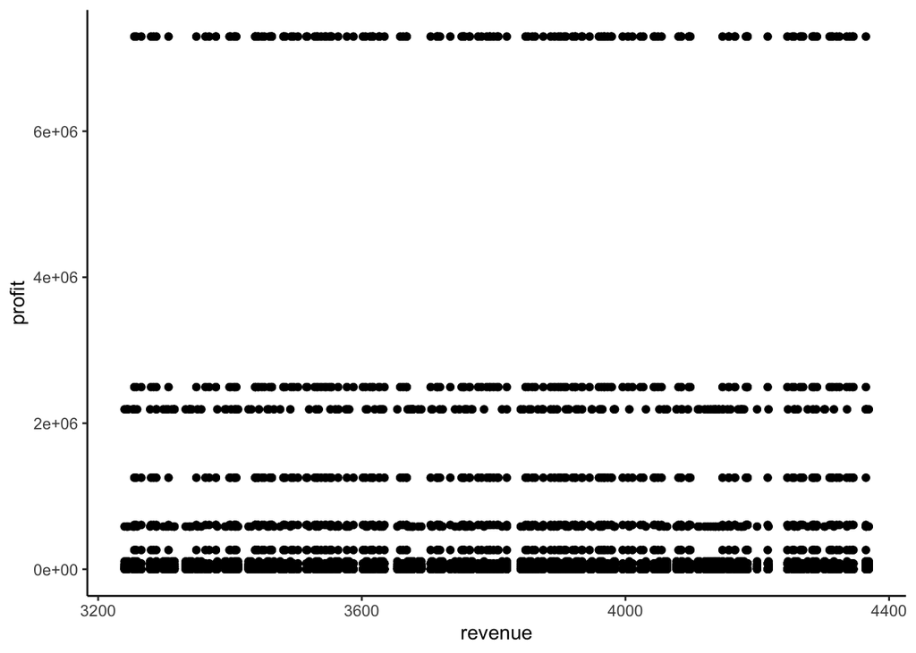

```r
rev_prof_plot <- ggplot(data = profit, aes(x = revenue, y = profit)) +
  geom_point() +
  theme_classic()
rev_prof_plot
```

# Paragraph of interpretation

Here, we built a model to estimate the profit from almond farming taking climatic variables into account (minimum temperature in February and total precipitation in January) to predict the almond yield, then we incorporated a parameter for the revenue per acre, since the value of almonds can vary quite a bit, and a parameter for the cost of irrigation, as we expect the cost to irrigate a farm to vary as well. We also incorporated the cost of non-irrigation tasks. We were interested in how sensitive the model was to **changes in almond revenue** and **changes in irrigation costs**, so we performed sensitivity analyses on these variables. We varied revenue by 10%, as almond revenue in California historically varied that much. We varied the cost of irrigation by 10% as well, as that seemed like a reasonable amount of variability to us. We found that profit did not have a strong linear relationship with a variation either revenue nor profit, as was seen in our scatterplots.

NOTES:

We will use the output for mean_almond_yeild from our almond_yield function as input into a function that estimates profit given a revenue (in $/ton)

- compute_profit_fromalmonds
  - inputs: mean_almond_yield, revenue, cost
  - outputs: single dataframe with columns for * profit * year??

Profit = Yield*Revenue - Non-irrigation_cost + irrigation_cost

Where: Profit: annual profit in $/acre

Yield = annual almond yield from yield function in tons/acre Revenue = revenue from selling almonds in $/ton Note: end up with units $/acre

Cost = cost of production per acre (est: $3,897 per acre) Note: end up with units $/acre

Could do something more fun like Cost = non-irrigation cost + irrigation cost and just look at varying irrigation costs in $/acre

Parameters we can vary:

1: Revenue (Over a range: 0.90 - 2.10 dollars per POUND, so first convert to $ per ton (1 pound = 0.0005 tons; so 0.9 dollars per pound is 0.9/0.0005 dollars per ton = 1800 dollars per ton & 2.10 dollars per pound is 4200 dollars per ton))

2: Annual Cost of production: how much do we want to vary this? Do we want to just do a piece? Plots we should make:

Parm 1: Revenue

1: Boxplot showing parm uncertainty (with ?? on x axis) 2: Boxplot showing mean of parm across the range of uncertainty w the output on x axis 3: Scatterplot of parm vs output showing relationship of how parm influences the results

Parm 2: Cost

1: Boxplot showing parm uncertainty (with ?? on x axis) 2: Boxplot showing mean of parm across the range of uncertainty w the output on x axis 3: Scatterplot of parm vs output showing relationship of how parm influences the results